[**Imtiaj.**](https://imtiajiqbalmahfuj.github.io/index.html#top)

# Predicting Cascading Transport Network Failures under Multi-Hazard Scenarios

### Unsupervised Graph Autoencoders (GAE) and GeoAI for Road Criticality Ranking in Chattogram

> *Mapping the cascading vulnerabilities of Chattogram's transport grid using Graph Neural Networks and Explainable AI 🚀🗺️*

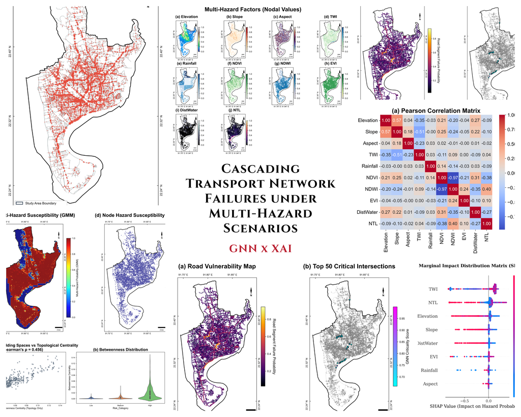

> **Author:** Imtiaj Iqbal Mahfuj

## 📝 Overview

This project explores **spatial patterns**, integrates **remote sensing datasets**, and applies **geospatial Python tools** to visualize and analyze the cascading vulnerabilities of urban transportation networks. Traditional transport vulnerability assessments heavily rely on geometric centrality metrics, which fail to accurately model the systemic and cascading nature of infrastructure failures under real-world climate stressors. By focusing on Chattogram—a coastal megacity constrained by extreme topography and rapid urbanization—this study bridges the gap between topological network science and environmental risk modeling.

The primary objective is to construct a resilient topological road network graph and evaluate it using an unsupervised Graph Autoencoder (GAE). By integrating satellite-derived multi-hazard exposure (flood and landslide risks) as node-level features, the model learns complex structural embedding spaces to identify and rank high-risk critical nodes without relying on historical failure data. Furthermore, Explainable AI (XAI) is employed to unpack the spatial and environmental drivers of these vulnerabilities.

This open-source framework significantly benefits urban planners, transportation engineers, researchers, and policy-makers in developing coastal regions. It provides a transparent, data-driven approach to disaster risk reduction, empowering decision-makers to prioritize infrastructure investments and emergency logistics planning ahead of compounding disaster events.

In summary, the methodology successfully extracts drivable networks via OSMnx, assigns high-resolution meteorological and topographical features from Google Earth Engine, and utilizes a PyTorch Geometric GAE to simulate infrastructure stress tests. The findings quantitatively prove that GNN-targeted failure scenarios degrade global network efficiency drastically faster than traditional geometric attacks.

## 🛠️ Tools & Technologies

## ⚙️ Methodology

[output not shown]

## 📊 Results & Insights

# Multi-Hazards Susceptibility Modeling and GeoAI Network Resilience

## INITIALIZATION AND IEEE VISUAL CONFIGURATION

```python
# Import base libraries for OS management and plotting
import os
import matplotlib.pyplot as plt
import numpy as np
import pandas as pd
import ee
import geemap
import osmnx as ox
import networkx as nx
import geopandas as gpd
from shapely.geometry import shape
from matplotlib_scalebar.scalebar import ScaleBar
import matplotlib.patches as mpatches

# Configure OSMnx
ox.settings.use_cache = True
ox.settings.log_console = True

# Journal Publication Styling (Strict Serif, High DPI)
plt.rcParams.update({
    'font.family': 'sans-serif',
    'font.sans-serif': ['Arial', 'Helvetica', 'DejaVu Sans'],
    'text.usetex': False,            # Prevents LaTeX rendering engines from introducing blurry halos
    'mathtext.fontset': 'cm',        # Standard clean math typography block
    'font.size': 13,
    'axes.titlesize': 14,
    'axes.labelsize': 14,
    'xtick.labelsize': 14,
    'ytick.labelsize': 14,
    'legend.fontsize': 12,
    'figure.dpi': 500,               # Maintained high resolution
    'savefig.dpi': 500,
    'savefig.bbox': 'tight'
})

# Create a dedicated directory to save IEEE plots
# OUTPUT_DIR = "Manuscript_Plots"
OUTPUT_DIR = "Manuscript_Plots"
os.makedirs(OUTPUT_DIR, exist_ok=True)
```

```python
ee.Authenticate()
ee.Initialize()
```

```python
from matplotlib.ticker import MaxNLocator, FuncFormatter

def apply_custom_map_style(ax, reference_gdf, title="", tight=False, is_factor_grid=False):
    # 1. Handle axis ticks and labels based on plot density
    if is_factor_grid:
        # Hide top and right text ticks entirely to stop grid collision
        ax.tick_params(top=True, bottom=True, left=True, right=True,
                       direction='in', labeltop=False, labelbottom=True,
                       labelleft=True, labelright=False, pad=4, labelsize=7)
        # Tighten tick label density
        ax.xaxis.set_major_locator(MaxNLocator(nbins=3, prune='both'))
        ax.yaxis.set_major_locator(MaxNLocator(nbins=3, prune='both'))
        ax.set_title(title, pad=12, fontweight='bold', fontsize=14)
    else:
        # Show all 4 sides for standalone main maps
        ax.tick_params(top=True, bottom=True, left=True, right=True,
                       direction='in', labeltop=True, labelbottom=True,
                       labelleft=True, labelright=True, pad=5, labelsize=8)
        ax.xaxis.set_major_locator(MaxNLocator(nbins=4, prune='both'))
        ax.yaxis.set_major_locator(MaxNLocator(nbins=4, prune='both'))
        ax.set_title(title, pad=30, fontweight='bold', fontsize=20)

    ax.tick_params(axis='y', labelrotation=90)

    # 2. Format coordinate text labels
    ax.xaxis.set_major_formatter(FuncFormatter(lambda x, _: f"{x:.2f}° E"))
    ax.yaxis.set_major_formatter(FuncFormatter(lambda y, _: f"{y:.2f}° N"))

    # 3. Add Scale Bar and North Arrow Elements
    projected_centroid = reference_gdf.to_crs(epsg=32646).geometry.centroid.to_crs(epsg=4326)
    center_lat = projected_centroid.y.iloc[0]
    deg_points = gpd.GeoSeries([Point(91.0, center_lat), Point(92.0, center_lat)], crs="EPSG:4326").to_crs(epsg=32646)
    meters_per_degree = deg_points.iloc[0].distance(deg_points.iloc[1])

    scalebar = ScaleBar(dx=meters_per_degree, units="m", location="lower right",
                        box_alpha=0.7, color='black', font_properties={'size': 7})
    ax.add_artist(scalebar)

    ax.annotate('N', xy=(0.93, 0.93), xytext=(0.93, 0.87),
                arrowprops=dict(facecolor='black', width=1.0, headwidth=4, shrink=0.05),
                ha='center', va='center', fontweight='bold', fontsize=8, xycoords='axes fraction')

    # 4. Handle Frame Boundaries with breathing margins
    bounds = reference_gdf.total_bounds
    padding = 0.006 if tight else 0.016
    ax.set_xlim(bounds[0] - padding, bounds[2] + padding)
    ax.set_ylim(bounds[1] - padding, bounds[3] + padding)
```